# Part I - (Ford GoBike System Data)

## Introduction

> This data set includes information about individual rides made in a bike-sharing system covering the greater San Francisco Bay area.

> **Rubric Tip**: Your code should not generate any errors, and should use functions, loops where possible to reduce repetitive code. Prefer to use functions to reuse code statements.

> **Rubric Tip**: Document your approach and findings in markdown cells. Use comments and docstrings in code cells to document the code functionality.

> **Rubric Tip**: Markup cells should have headers and text that organize your thoughts, findings, and what you plan on investigating next.

## Preliminary Wrangling

```python
# importing all packages and set plots to be embedded inline
import numpy as np
import pandas as pd
import matplotlib.pyplot as plt
import seaborn as sb

%matplotlib inline
```

**Declaring a functions to reuse code statements to avoid repetitive code**

```python
def label(x,y,t):
    """
    Args:
    x (str): x-axis
    y (str): y-axis
    t (str): main title

    Returns:
    None
    """

    plt.xlabel(x)
    plt.ylabel(y)
    plt.title(t)
    plt.show()
```

```python
 # setting the default color for seaborn my plots
base_color = sb.color_palette()[0]
```

> **Loading in the dataset and hence, I will describe its properties through the questions below**

```python
# loading in the dataset into a pandas dataframe, print statistics

data = pd.read_csv('201902-fordgobike-tripdata.csv')
```

> **Gaining high-level overview of data shape and composition**

```python
# viewing info of data

data.info()
```

```
<class 'pandas.core.frame.DataFrame'>
RangeIndex: 183412 entries, 0 to 183411
Data columns (total 16 columns):
 #   Column                   Non-Null Count   Dtype
---  ------                   --------------   -----
 0   duration_sec             183412 non-null  int64
 1   start_time               183412 non-null  object
 2   end_time                 183412 non-null  object
 3   start_station_id         183215 non-null  float64
 4   start_station_name       183215 non-null  object
 5   start_station_latitude   183412 non-null  float64
 6   start_station_longitude  183412 non-null  float64
 7   end_station_id           183215 non-null  float64
 8   end_station_name         183215 non-null  object
 9   end_station_latitude     183412 non-null  float64
 10  end_station_longitude    183412 non-null  float64
 11  bike_id                  183412 non-null  int64
 12  user_type                183412 non-null  object
 13  member_birth_year        175147 non-null  float64
 14  member_gender            175147 non-null  object
 15  bike_share_for_all_trip  183412 non-null  object
dtypes: float64(7), int64(2), object(7)
memory usage: 22.4+ MB
```

```python
# viewing descriptive statistics for numeric variables in the data

print(data.describe())
```

```
        duration_sec  start_station_id  start_station_latitude  \
count  183412.000000     183215.000000           183412.000000
mean      726.078435        138.590427               37.771223
std      1794.389780        111.778864                0.099581
min        61.000000          3.000000               37.317298
25%       325.000000         47.000000               37.770083
50%       514.000000        104.000000               37.780760
75%       796.000000        239.000000               37.797280
max     85444.000000        398.000000               37.880222

       start_station_longitude  end_station_id  end_station_latitude  \
count            183412.000000   183215.000000         183412.000000
mean               -122.352664      136.249123             37.771427
std                   0.117097      111.515131              0.099490
min                -122.453704        3.000000             37.317298
25%                -122.412408       44.000000             37.770407
50%                -122.398285      100.000000             37.781010
75%                -122.286533      235.000000             37.797320
max                -121.874119      398.000000             37.880222

       end_station_longitude        bike_id  member_birth_year
count          183412.000000  183412.000000      175147.000000
mean             -122.352250    4472.906375        1984.806437
std                 0.116673    1664.383394          10.116689
min              -122.453704      11.000000        1878.000000
25%              -122.411726    3777.000000        1980.000000
50%              -122.398279    4958.000000        1987.000000
75%              -122.288045    5502.000000        1992.000000
max              -121.874119    6645.000000        2001.000000
```

```python
#viewing the shape (count of rows and columns) of the dataset

print(data.shape)
```

```
(183412, 16)
```

```python
#viewing the data type in the dataset

print(data.dtypes)
```

```
duration_sec                 int64
start_time                  object
end_time                    object
start_station_id           float64
start_station_name          object
start_station_latitude     float64
start_station_longitude    float64
end_station_id             float64
end_station_name            object
end_station_latitude       float64
end_station_longitude      float64
bike_id                      int64
user_type                   object
member_birth_year          float64
member_gender               object
bike_share_for_all_trip     object
dtype: object
```

```python
#viewing number of unique records in the dataset

data.nunique()
```

```
duration_sec                 4752
start_time                 183401
end_time                   183397
start_station_id              329
start_station_name            329
start_station_latitude        334
start_station_longitude       335
end_station_id                329
end_station_name              329
end_station_latitude          335
end_station_longitude         335
bike_id                      4646
user_type                       2
member_birth_year              75
member_gender                   3
bike_share_for_all_trip         2
dtype: int64
```

```python
# Checking for duplicates
data.duplicated().sum()
```

```
0
```

```python
#displaying all the columns in the dataset

data.columns
```

```
Index(['duration_sec', 'start_time', 'end_time', 'start_station_id',
       'start_station_name', 'start_station_latitude',
       'start_station_longitude', 'end_station_id', 'end_station_name',
       'end_station_latitude', 'end_station_longitude', 'bike_id', 'user_type',
       'member_birth_year', 'member_gender', 'bike_share_for_all_trip'],
      dtype='object')
```

```python
#viewing a few records of the data for visual assessment

data.head(20)
```

|  | duration_sec | start_time | end_time | start_station_id | start_station_name | start_station_latitude | start_station_longitude | end_station_id | end_station_name | end_station_latitude | end_station_longitude | bike_id | user_type | member_birth_year | member_gender | bike_share_for_all_trip |
| --- | --- | --- | --- | --- | --- | --- | --- | --- | --- | --- | --- | --- | --- | --- | --- | --- |
| 0 | 52185 | 2019-02-28 17:32:10.1450 | 2019-03-01 08:01:55.9750 | 21.0 | Montgomery St BART Station (Market St at 2nd St) | 37.789625 | -122.400811 | 13.0 | Commercial St at Montgomery St | 37.794231 | -122.402923 | 4902 | Customer | 1984.0 | Male | No |
| 1 | 42521 | 2019-02-28 18:53:21.7890 | 2019-03-01 06:42:03.0560 | 23.0 | The Embarcadero at Steuart St | 37.791464 | -122.391034 | 81.0 | Berry St at 4th St | 37.775880 | -122.393170 | 2535 | Customer | NaN | NaN | No |
| 2 | 61854 | 2019-02-28 12:13:13.2180 | 2019-03-01 05:24:08.1460 | 86.0 | Market St at Dolores St | 37.769305 | -122.426826 | 3.0 | Powell St BART Station (Market St at 4th St) | 37.786375 | -122.404904 | 5905 | Customer | 1972.0 | Male | No |
| 3 | 36490 | 2019-02-28 17:54:26.0100 | 2019-03-01 04:02:36.8420 | 375.0 | Grove St at Masonic Ave | 37.774836 | -122.446546 | 70.0 | Central Ave at Fell St | 37.773311 | -122.444293 | 6638 | Subscriber | 1989.0 | Other | No |
| 4 | 1585 | 2019-02-28 23:54:18.5490 | 2019-03-01 00:20:44.0740 | 7.0 | Frank H Ogawa Plaza | 37.804562 | -122.271738 | 222.0 | 10th Ave at E 15th St | 37.792714 | -122.248780 | 4898 | Subscriber | 1974.0 | Male | Yes |
| 5 | 1793 | 2019-02-28 23:49:58.6320 | 2019-03-01 00:19:51.7600 | 93.0 | 4th St at Mission Bay Blvd S | 37.770407 | -122.391198 | 323.0 | Broadway at Kearny | 37.798014 | -122.405950 | 5200 | Subscriber | 1959.0 | Male | No |
| 6 | 1147 | 2019-02-28 23:55:35.1040 | 2019-03-01 00:14:42.5880 | 300.0 | Palm St at Willow St | 37.317298 | -121.884995 | 312.0 | San Jose Diridon Station | 37.329732 | -121.901782 | 3803 | Subscriber | 1983.0 | Female | No |
| 7 | 1615 | 2019-02-28 23:41:06.7660 | 2019-03-01 00:08:02.7560 | 10.0 | Washington St at Kearny St | 37.795393 | -122.404770 | 127.0 | Valencia St at 21st St | 37.756708 | -122.421025 | 6329 | Subscriber | 1989.0 | Male | No |
| 8 | 1570 | 2019-02-28 23:41:48.7900 | 2019-03-01 00:07:59.7150 | 10.0 | Washington St at Kearny St | 37.795393 | -122.404770 | 127.0 | Valencia St at 21st St | 37.756708 | -122.421025 | 6548 | Subscriber | 1988.0 | Other | No |
| 9 | 1049 | 2019-02-28 23:49:47.6990 | 2019-03-01 00:07:17.0250 | 19.0 | Post St at Kearny St | 37.788975 | -122.403452 | 121.0 | Mission Playground | 37.759210 | -122.421339 | 6488 | Subscriber | 1992.0 | Male | No |
| 10 | 458 | 2019-02-28 23:57:57.2110 | 2019-03-01 00:05:35.4350 | 370.0 | Jones St at Post St | 37.787327 | -122.413278 | 43.0 | San Francisco Public Library (Grove St at Hyde... | 37.778768 | -122.415929 | 5318 | Subscriber | 1996.0 | Female | Yes |
| 11 | 506 | 2019-02-28 23:56:55.5400 | 2019-03-01 00:05:21.7330 | 44.0 | Civic Center/UN Plaza BART Station (Market St ... | 37.781074 | -122.411738 | 343.0 | Bryant St at 2nd St | 37.783172 | -122.393572 | 5848 | Subscriber | 1993.0 | Male | No |
| 12 | 1176 | 2019-02-28 23:45:12.6510 | 2019-03-01 00:04:49.1840 | 127.0 | Valencia St at 21st St | 37.756708 | -122.421025 | 323.0 | Broadway at Kearny | 37.798014 | -122.405950 | 5328 | Customer | 1990.0 | Male | No |
| 13 | 915 | 2019-02-28 23:49:06.0620 | 2019-03-01 00:04:21.8670 | 252.0 | Channing Way at Shattuck Ave | 37.865847 | -122.267443 | 244.0 | Shattuck Ave at Hearst Ave | 37.873676 | -122.268487 | 5101 | Subscriber | NaN | NaN | No |
| 14 | 395 | 2019-02-28 23:56:26.8480 | 2019-03-01 00:03:01.9470 | 243.0 | Bancroft Way at College Ave | 37.869360 | -122.254337 | 252.0 | Channing Way at Shattuck Ave | 37.865847 | -122.267443 | 4786 | Subscriber | 1988.0 | Male | No |
| 15 | 208 | 2019-02-28 23:59:18.5480 | 2019-03-01 00:02:47.2280 | 349.0 | Howard St at Mary St | 37.781010 | -122.405666 | 60.0 | 8th St at Ringold St | 37.774520 | -122.409449 | 6361 | Subscriber | 1993.0 | Male | Yes |
| 16 | 548 | 2019-02-28 23:50:41.6070 | 2019-02-28 23:59:49.9530 | 131.0 | 22nd St at Dolores St | 37.755000 | -122.425728 | 71.0 | Broderick St at Oak St | 37.773063 | -122.439078 | 6572 | Subscriber | 1981.0 | Male | No |
| 17 | 674 | 2019-02-28 23:48:25.0950 | 2019-02-28 23:59:40.0920 | 74.0 | Laguna St at Hayes St | 37.776435 | -122.426244 | 336.0 | Potrero Ave and Mariposa St | 37.763281 | -122.407377 | 5343 | Subscriber | 1975.0 | Male | No |
| 18 | 557 | 2019-02-28 23:49:01.8510 | 2019-02-28 23:58:19.8090 | 321.0 | 5th St at Folsom | 37.780146 | -122.403071 | 75.0 | Market St at Franklin St | 37.773793 | -122.421239 | 5854 | Subscriber | 1990.0 | Male | No |
| 19 | 874 | 2019-02-28 23:43:05.1830 | 2019-02-28 23:57:39.7960 | 180.0 | Telegraph Ave at 23rd St | 37.812678 | -122.268773 | 180.0 | Telegraph Ave at 23rd St | 37.812678 | -122.268773 | 5629 | Customer | 1978.0 | Male | No |

```python
data.sample(16)
```

|  | duration_sec | start_time | end_time | start_station_id | start_station_name | start_station_latitude | start_station_longitude | end_station_id | end_station_name | end_station_latitude | end_station_longitude | bike_id | user_type | member_birth_year | member_gender | bike_share_for_all_trip |
| --- | --- | --- | --- | --- | --- | --- | --- | --- | --- | --- | --- | --- | --- | --- | --- | --- |
| 96827 | 214 | 2019-02-15 09:46:04.1930 | 2019-02-15 09:49:38.8900 | 239.0 | Bancroft Way at Telegraph Ave | 37.868813 | -122.258764 | 256.0 | Hearst Ave at Euclid Ave | 37.875112 | -122.260553 | 4907 | Subscriber | 1998.0 | Male | No |
| 84407 | 6199 | 2019-02-17 16:12:15.5950 | 2019-02-17 17:55:34.9080 | 3.0 | Powell St BART Station (Market St at 4th St) | 37.786375 | -122.404904 | 21.0 | Montgomery St BART Station (Market St at 2nd St) | 37.789625 | -122.400811 | 6253 | Customer | 1997.0 | Male | No |
| 182981 | 634 | 2019-02-01 07:22:46.7730 | 2019-02-01 07:33:21.1930 | 44.0 | Civic Center/UN Plaza BART Station (Market St ... | 37.781074 | -122.411738 | 116.0 | Mississippi St at 17th St | 37.764802 | -122.394771 | 4943 | Subscriber | 1959.0 | Male | No |
| 131741 | 606 | 2019-02-09 10:57:46.8010 | 2019-02-09 11:07:53.5150 | 61.0 | Howard St at 8th St | 37.776513 | -122.411306 | 67.0 | San Francisco Caltrain Station 2 (Townsend St... | 37.776639 | -122.395526 | 1360 | Subscriber | 1986.0 | Female | No |
| 60270 | 389 | 2019-02-20 18:51:34.2180 | 2019-02-20 18:58:03.4170 | 386.0 | 24th St at Bartlett St | 37.752105 | -122.419724 | 146.0 | 30th St at San Jose Ave | 37.742314 | -122.423181 | 5354 | Subscriber | 1992.0 | Male | No |
| 109864 | 1156 | 2019-02-12 18:20:26.8910 | 2019-02-12 18:39:43.0270 | 363.0 | Salesforce Transit Center (Natoma St at 2nd St) | 37.787492 | -122.398285 | 123.0 | Folsom St at 19th St | 37.760594 | -122.414817 | 2576 | Subscriber | 1995.0 | Male | No |
| 77623 | 274 | 2019-02-19 06:25:55.6870 | 2019-02-19 06:30:30.3800 | 108.0 | 16th St Mission BART | 37.764710 | -122.419957 | 100.0 | Bryant St at 15th St | 37.767100 | -122.410662 | 5752 | Subscriber | NaN | NaN | No |
| 131521 | 1639 | 2019-02-09 11:50:26.5570 | 2019-02-09 12:17:46.4030 | 10.0 | Washington St at Kearny St | 37.795393 | -122.404770 | 10.0 | Washington St at Kearny St | 37.795393 | -122.404770 | 4962 | Subscriber | 1974.0 | Male | Yes |
| 50931 | 315 | 2019-02-21 18:34:20.2870 | 2019-02-21 18:39:36.2030 | 246.0 | Berkeley Civic Center | 37.869060 | -122.270556 | 266.0 | Parker St at Fulton St | 37.862464 | -122.264791 | 5598 | Subscriber | 1988.0 | Male | No |
| 123934 | 396 | 2019-02-11 08:58:14.1380 | 2019-02-11 09:04:50.7820 | 115.0 | Jackson Playground | 37.765026 | -122.398773 | 89.0 | Division St at Potrero Ave | 37.769218 | -122.407646 | 2769 | Subscriber | 1991.0 | Female | No |
| 166132 | 934 | 2019-02-04 19:38:39.5930 | 2019-02-04 19:54:14.2420 | 134.0 | Valencia St at 24th St | 37.752428 | -122.420628 | 55.0 | Webster St at Grove St | 37.777053 | -122.429558 | 5474 | Subscriber | 1995.0 | Male | No |
| 8226 | 306 | 2019-02-28 08:34:17.3580 | 2019-02-28 08:39:23.6750 | 66.0 | 3rd St at Townsend St | 37.778742 | -122.392741 | 26.0 | 1st St at Folsom St | 37.787290 | -122.394380 | 5030 | Subscriber | 1984.0 | Female | No |
| 127829 | 469 | 2019-02-10 14:48:46.1890 | 2019-02-10 14:56:36.1710 | 72.0 | Page St at Scott St | 37.772406 | -122.435650 | 375.0 | Grove St at Masonic Ave | 37.774836 | -122.446546 | 4658 | Subscriber | 1986.0 | Female | No |
| 132746 | 435 | 2019-02-08 22:27:21.3550 | 2019-02-08 22:34:36.7110 | 296.0 | 5th St at Virginia St | 37.325998 | -121.877120 | 311.0 | Paseo De San Antonio at 2nd St | 37.333798 | -121.886943 | 4000 | Subscriber | 1996.0 | Male | Yes |
| 19148 | 403 | 2019-02-26 17:27:57.7190 | 2019-02-26 17:34:40.7190 | 93.0 | 4th St at Mission Bay Blvd S | 37.770407 | -122.391198 | 345.0 | Hubbell St at 16th St | 37.766483 | -122.398279 | 5202 | Subscriber | 1983.0 | Male | No |
| 144710 | 704 | 2019-02-07 11:17:26.7540 | 2019-02-07 11:29:11.4210 | 5.0 | Powell St BART Station (Market St at 5th St) | 37.783899 | -122.408445 | 92.0 | Mission Bay Kids Park | 37.772301 | -122.393028 | 459 | Subscriber | 1981.0 | Male | Yes |

```python
# checking for missing data
data.isnull().sum()
```

```
duration_sec                  0
start_time                    0
end_time                      0
start_station_id            197
start_station_name          197
start_station_latitude        0
start_station_longitude       0
end_station_id              197
end_station_name            197
end_station_latitude          0
end_station_longitude         0
bike_id                       0
user_type                     0
member_birth_year          8265
member_gender              8265
bike_share_for_all_trip       0
dtype: int64
```

```python
data.isna().sample(6)
```

|  | duration_sec | start_time | end_time | start_station_id | start_station_name | start_station_latitude | start_station_longitude | end_station_id | end_station_name | end_station_latitude | end_station_longitude | bike_id | user_type | member_birth_year | member_gender | bike_share_for_all_trip |
| --- | --- | --- | --- | --- | --- | --- | --- | --- | --- | --- | --- | --- | --- | --- | --- | --- |
| 182310 | False | False | False | False | False | False | False | False | False | False | False | False | False | False | False | False |
| 81665 | False | False | False | False | False | False | False | False | False | False | False | False | False | False | False | False |
| 108110 | False | False | False | False | False | False | False | False | False | False | False | False | False | False | False | False |
| 36284 | False | False | False | False | False | False | False | False | False | False | False | False | False | False | False | False |
| 82944 | False | False | False | False | False | False | False | False | False | False | False | False | False | False | False | False |
| 140407 | False | False | False | False | False | False | False | False | False | False | False | False | False | False | False | False |

```python
data.sample(4)
```

|  | duration_sec | start_time | end_time | start_station_id | start_station_name | start_station_latitude | start_station_longitude | end_station_id | end_station_name | end_station_latitude | end_station_longitude | bike_id | user_type | member_birth_year | member_gender | bike_share_for_all_trip |
| --- | --- | --- | --- | --- | --- | --- | --- | --- | --- | --- | --- | --- | --- | --- | --- | --- |
| 13616 | 831 | 2019-02-27 15:18:45.4540 | 2019-02-27 15:32:36.6120 | 28.0 | The Embarcadero at Bryant St | 37.787168 | -122.388098 | 324.0 | Union Square (Powell St at Post St) | 37.788300 | -122.408531 | 5559 | Subscriber | 1990.0 | Female | No |
| 58359 | 700 | 2019-02-21 06:45:29.6640 | 2019-02-21 06:57:10.1910 | 67.0 | San Francisco Caltrain Station 2 (Townsend St... | 37.776639 | -122.395526 | 8.0 | The Embarcadero at Vallejo St | 37.799953 | -122.398525 | 5233 | Subscriber | 1972.0 | Female | No |
| 76105 | 834 | 2019-02-19 08:30:00.9090 | 2019-02-19 08:43:55.2720 | 6.0 | The Embarcadero at Sansome St | 37.804770 | -122.403234 | 30.0 | San Francisco Caltrain (Townsend St at 4th St) | 37.776598 | -122.395282 | 5815 | Subscriber | 1987.0 | Male | No |
| 24461 | 1220 | 2019-02-25 18:01:09.5820 | 2019-02-25 18:21:29.8680 | 16.0 | Steuart St at Market St | 37.794130 | -122.394430 | 85.0 | Church St at Duboce Ave | 37.770083 | -122.429156 | 2241 | Subscriber | 1979.0 | Male | No |

### What is the structure of your dataset?

> There are **183412 entries** in the dataset with **16 features(columns)** namley:**(duration_sec, start_time, end_time, start_station_id, start_station_name, start_station_latitude, start_station_longitude, end_station_id, end_station_name, end_station_latitude, end_station_longitude, bike_id, user_type, member_birth_year, member_gender, bike_share_for_all_trip)**
> - There were missing data in the dataset : start_station_id - 197, start_station_name - 197, end_station_id - 197, end_station_name - 197, member_birth_year - 8265, member_gender - 8265

### What is/are the main feature(s) of interest in your dataset?

## > I am interested in figuring out what features are best for:

- How long does the average trip take?
- Does the above depend on if a user is a subscriber or customer?
- Is gender associated with bike sharing for all trips?
- What group of user-type patronise Ford GoBike System the most?
- Does age group of members (count of member_birth-year) have a relationship with the duration of bike ride trips?

### What features in the dataset do you think will help support your investigation into your feature(s) of interest?

> I think that user type(subscriber or customer) will have a strong effect on how long the average trip take. Also I think gender might not neccesarily affect the bike-sharing for all trips. Again, I also think member's age might affect the how long (duration) of the average trip.

#### Tidying up the data before exploratory analysis

```python
# Making a copy of the data
# dropping NAN and nulls values in df to get a quality

df = data.copy()
df = df.dropna(axis=0)
```

```python
df['member_birth_year'] = df['member_birth_year'].astype('int')
```

```python
df['age_of_member'] = df.apply(lambda x: 2019 - x['member_birth_year'], axis = 1)
```

```python
df.dtypes
```

```
duration_sec                 int64
start_time                  object
end_time                    object
start_station_id           float64
start_station_name          object
start_station_latitude     float64
start_station_longitude    float64
end_station_id             float64
end_station_name            object
end_station_latitude       float64
end_station_longitude      float64
bike_id                      int64
user_type                   object
member_birth_year            int64
member_gender               object
bike_share_for_all_trip     object
age_of_member                int64
dtype: object
```

```python
df.member_birth_year.head(3)
```

```
0    1984
2    1972
3    1989
Name: member_birth_year, dtype: int64
```

## Univariate Exploration

> In this section, investigate distributions of individual variables.

> **Rubric Tip**: Use the "Question-Visualization-Observations" framework throughout the exploration. This framework involves **asking a question from the data, creating a visualization to find answers, and then recording observations after each visualisation.**

```python
# start with a standard-scaled plot
df.head(3)
```

|  | duration_sec | start_time | end_time | start_station_id | start_station_name | start_station_latitude | start_station_longitude | end_station_id | end_station_name | end_station_latitude | end_station_longitude | bike_id | user_type | member_birth_year | member_gender | bike_share_for_all_trip | age_of_member |
| --- | --- | --- | --- | --- | --- | --- | --- | --- | --- | --- | --- | --- | --- | --- | --- | --- | --- |
| 0 | 52185 | 2019-02-28 17:32:10.1450 | 2019-03-01 08:01:55.9750 | 21.0 | Montgomery St BART Station (Market St at 2nd St) | 37.789625 | -122.400811 | 13.0 | Commercial St at Montgomery St | 37.794231 | -122.402923 | 4902 | Customer | 1984 | Male | No | 35 |
| 2 | 61854 | 2019-02-28 12:13:13.2180 | 2019-03-01 05:24:08.1460 | 86.0 | Market St at Dolores St | 37.769305 | -122.426826 | 3.0 | Powell St BART Station (Market St at 4th St) | 37.786375 | -122.404904 | 5905 | Customer | 1972 | Male | No | 47 |
| 3 | 36490 | 2019-02-28 17:54:26.0100 | 2019-03-01 04:02:36.8420 | 375.0 | Grove St at Masonic Ave | 37.774836 | -122.446546 | 70.0 | Central Ave at Fell St | 37.773311 | -122.444293 | 6638 | Subscriber | 1989 | Other | No | 30 |

### Question 1: Who are the users of Ford GoBike System?

```python
# Count the frequency of unique values in the `user_type` column of df dataframe

type_order = df['user_type'].value_counts().index
type_orders = df['user_type'].value_counts()
print(type_orders)
```

```
Subscriber    158386
Customer       16566
Name: user_type, dtype: int64
```

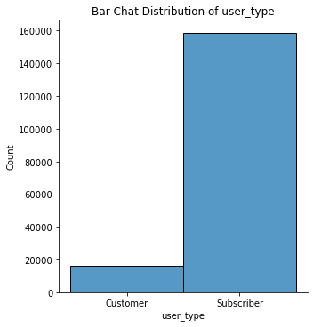

```python
# Plotting df user_type on a vertical bar chart
sb.displot(df['user_type'], kind='hist').set(title='Bar Chat Distribution of user_type');
```

### Question 2: What the age (using date of birth) distribution of users?

[figure not shown]

```python
member_birth = df['member_birth_year'].value_counts().sort_index()
member_birth.plot(kind='bar', figsize=(17,5), rot=0)
#get current tick labels
pos, lab=plt.xticks()

#set new tick labels (every second one)
plt.xticks(pos[::2], lab[::2]);
label('Year_of_birth', 'Count', 'Cumulative frequency plot of member_birth_year')
```

[figure not shown]

```python
member_birth = df['age_of_member'].value_counts().sort_index()
member_birth.plot(kind='bar', figsize=(24,5), rot=0)

label('Age of member', 'Count', 'Cumulative frequency plot of age of member')
```

> **From the bar plot, it is age 31 is identified as the age with highest count among users, followed by ages 26, 30, 29, 28, to mention but a few respectively**.

[figure not shown]

```python
#viewing the hist distribution of their ages
plt.figure(figsize=[20, 5])
plt.hist(data = df, x = 'age_of_member')
label('Age of member', 'Count', 'Histogram plot of depicting the distribution of duration_sec')
```

[figure not shown]

```python
binsize = 250
bins = np.arange(0, df['bike_id'].max()+3, binsize)

plt.figure(figsize=[20, 5])
plt.hist(data = df, x = 'bike_id', bins = bins)
label('duration_sec', 'Count', 'Histogram plot of depicting the distribution of duration_sec')
```

### Question 4: What is the nature of distribution of the following?

> - bike_id column
> - end_station_latitude
> - end_station_longitude
> - bike_share_for_all_trip

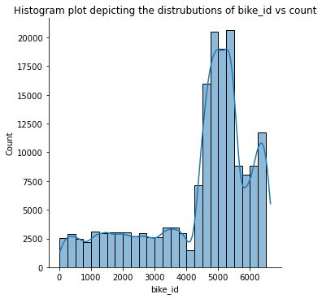

```python
sb.displot(df['bike_id'], bins=bins, kde=True).set(title='Histogram plot depicting the distrubutions of bike_id vs count');
```

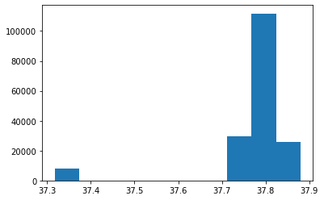

```python
plt.hist(df['end_station_latitude']);
```

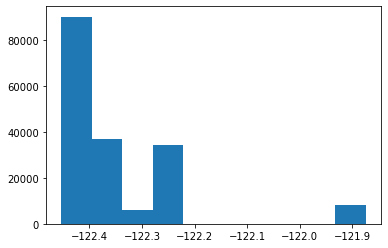

```python
plt.hist(df['end_station_longitude']);
```

### Question 5: what is the nature of bike_share_for_all_trip ?

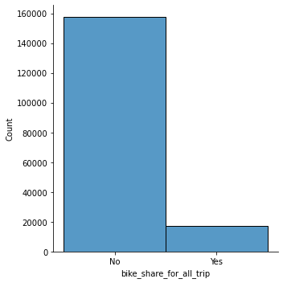

```python
#Plotting a displot to explore the this column
sb.displot(data=df, x='bike_share_for_all_trip', kind='hist');
```

```python
bike_share = df['bike_share_for_all_trip'].value_counts()
print(bike_share)
```

```
No     157606
Yes     17346
Name: bike_share_for_all_trip, dtype: int64
```

> **From the observation, `Yes` means there was sharing of bike for all trip and `No` means there was not sharing of same bike for some trips. Figuratively, `No bike sharing` recorded `157606 counts` and `Yes` also recorded `17346 counts`**

### Question 6: What is the distribution of gender of members(user_types) ?

[figure not shown]

```python
sb.displot(data=df, x='member_gender', kind='hist').set(title='Bar Chat Distribution of user_type');
```

```python
member_sex = df['member_gender'].value_counts()
(member_sex)
```

```
Male      130500
Female     40805
Other       3647
Name: member_gender, dtype: int64
```

> **From the exploratory analysis, we observed that the gender of Ford Bike System are mainly:**
> > - Male - 130500 counts
> > - Female - 40805
> > - Other - 3647

#### Of the features you investigated, were there any unusual distributions? Did you perform any operations on the data to tidy, adjust, or change the form of the data? If so, why did you do this?

> There was an usual distributions in `member_gender`, `member_birth_year` and `user_type`.
> - I created a new column `age_of_member` to know the ages of the users of Bike Ford System.

## Bivariate Exploration

> In this section, we investigate relationships between pairs of variables in the data. Making sure the variables that I cover here have been introduced in some fashion in the previous section (univariate exploration).

### Question 7: Is there a relation between variables `user_type` and `member_gender`?

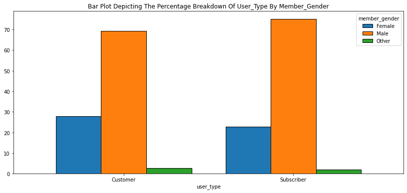

```python
df.groupby('user_type')['member_gender'].value_counts(normalize=True).unstack().mul(100).plot.bar(edgecolor='black', figsize=[14,6], rot=0, width=0.8);
plt.title('Bar plot depicting the percentage breakdown of user_type by member_gender'.title());
```

> **From the graph, it can be observed that "Male" gender was the highest among both the `Subscriber` user type and `Customer` user type, followed by "Female" gender in both user types. Last but not the least, "Other Genders" placed third place among both user types.**

### Question 8: Is there a relationship associated with user_type and bike_share_for_all_trip?

[figure not shown]

```python
sb.countplot(data = df, x = 'user_type', hue = 'bike_share_for_all_trip').set(title='Bar plot of relationship User_type  and member_gender');
```

> **From the countplot, it was found that the relationship between the two variable (user_type and bike_share_for_all_trip) was the "no-sharing of bike for all trip" which recorded the highest count among both the customer user_type and subscriber user_type**

### Question 9: Is there a relationship associated with gender of member and bike_share_for_all-trip?

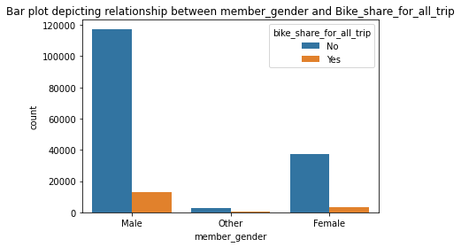

```python
sb.countplot(data = df, x = 'member_gender', hue = 'bike_share_for_all_trip').set(title='Bar plot depicting relationship between member_gender and Bike_share_for_all_trip');
```

> **From the graph, there was relationship between Female gender and other gender was `the sharing of bike for all trip`. However, `no-bike-sharing` was predominately more among Male gender, female gender and Other gender respectively**.

### Question 10: Is there a relationship between user_type and start_station longitude?

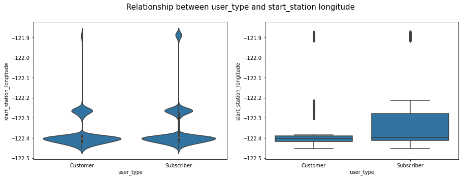

```python
# TWO PLOTS IN ONE FIGURE
plt.figure(figsize = [15, 5]).suptitle(' Relationship between user_type and start_station longitude', fontsize=15)

# LEFT plot: violin plot
plt.subplot(1, 2, 1)
#Let's return the axes object
ax1 = sb.violinplot(data=df, x='user_type', y='start_station_longitude', color=base_color)
plt.xticks(rotation=0);

# RIGHT plot: box plot
plt.subplot(1, 2, 2)
ax2 = sb.boxplot(data=df, x='user_type', y='start_station_longitude', color=base_color)
plt.xticks(rotation=0)
plt.ylim(ax1.get_ylim()); # set y-axis limits to be same as left plot
```

> **From the violin plot, it can be observed that the interquartile range (the black bar in the center of violin) varies from customer user_type (short) to subscriber user_type (long). Again, it can also be observed the third quartile tends to be smaller and also indicates the presence of outside points**.

### Question 11: Is there a relationship between user_type and station latitude?

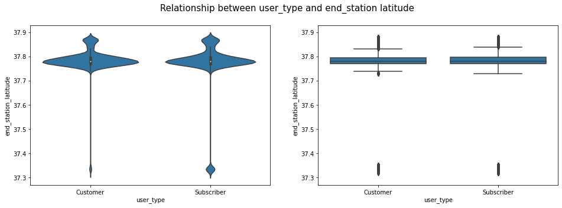

```python
# TWO PLOTS IN ONE FIGURE
plt.figure(figsize = [16, 5]).suptitle(' Relationship between user_type and end_station latitude', fontsize=15)

# LEFT plot: violin plot
plt.subplot(1, 2, 1)
#Let's return the axes object
ax1 = sb.violinplot(data=df, x='user_type', y='end_station_latitude', color=base_color)
plt.xticks(rotation=0);

# RIGHT plot: box plot
plt.subplot(1, 2, 2)
sb.boxplot(data=df, x='user_type', y='end_station_latitude', color=base_color)
plt.xticks(rotation=0);
plt.ylim(ax1.get_ylim()); # setting y-axis limits to be same as left plot
```

> **The violin and box plot indicate the presence of outside points. I would have to further invesigate the unsual distribution visualized in this plots**.

#### Talk about some of the relationships you observed in this part of the investigation. How did the feature(s) of interest vary with other features in the dataset?

> One of the relationships observed was the relationship between Female gender and other gender was the sharing of bike for all trip. However, no-bike-sharing was predominately among Male gender, female gender and Other gender respectively.In terms of population, the male gender recorded the highest counts across all other variable distribution, followed by female gender and other genders respectively.

#### Did you observe any interesting relationships between the other features (not the main feature(s) of interest)?

> Relationship between user_type and end_station latitude, and relationship between user_type and start_station longitude were intersting. However, I was not able to explore that in this project.

## Multivariate Exploration

> Creating plots of three or more variables to investigate my data even further.

### Question 12: Is there a relationship associated with member gender, age_of_member and end_station_longitude?

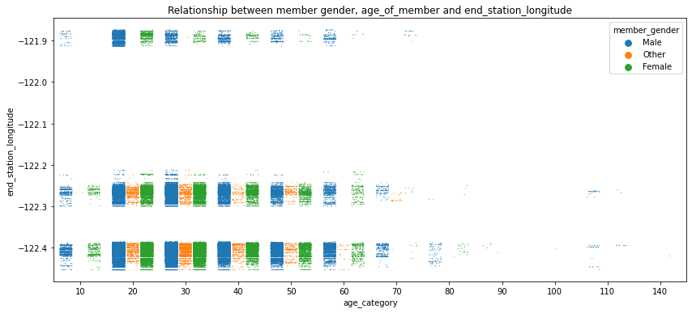

```python
#creating a categorical age variable using floor division.
df['age_category'] = ((df['age_of_member']//10)*10).astype(int)

#setting plot dimension
plt.figure(figsize=[14,6])

sb.stripplot(data=df, x='age_category', y='end_station_longitude', hue='member_gender',
            jitter=0.35, dodge=True, size=1)
plt.title('Relationship between member gender, age_of_member and end_station_longitude');
```

> **From the plot, it is observable that members of all genders with their ages less than 90years had lots of data points counts which were concentrated their respective end station longitude. This goes on to question " Do older people not finish or complete their ride to their destinations(end stations)?"; because the graph depicts fewer data points for members of ages 100years and above**.

#### Further exploration to Question 12

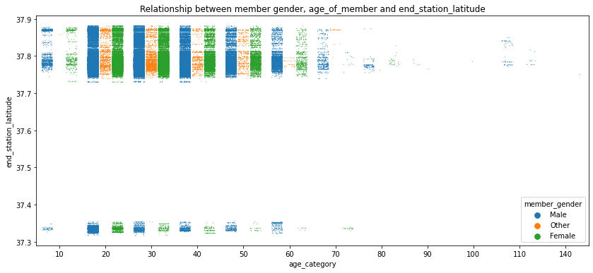

```python
#setting plot dimension
plt.figure(figsize=[14,6])

sb.stripplot(data=df, x='age_category', y='end_station_latitude', hue='member_gender',
            jitter=0.35, dodge=True, size=1)
plt.title('Relationship between member gender, age_of_member and end_station_latitude');
```

> **This plot further proves that it is possible that either older members of ages 100 and above are fewer when it comes to reaching their ride end station or fewer older people actually patronise Ford GoBike System**.

### Question 13: Is there a relationship between user_type, duration_sec and age_of_member variables?

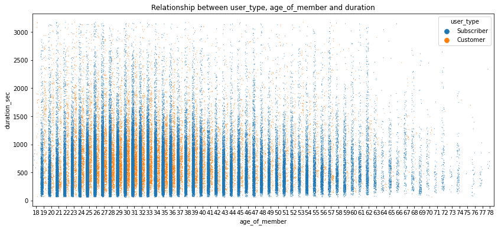

```python
plt.figure(figsize=[14,6])

sb.stripplot(data=df.query('duration_sec<duration_sec.quantile(0.99) and age_of_member<80'),
            x='age_of_member', y='duration_sec', hue='user_type',
            jitter=0.35, dodge=True, size=1)
plt.title('Relationship between user_type, age_of_member and duration');
```

### Question 14: Is there a relationship between gender of member, duration of ride and age of member?

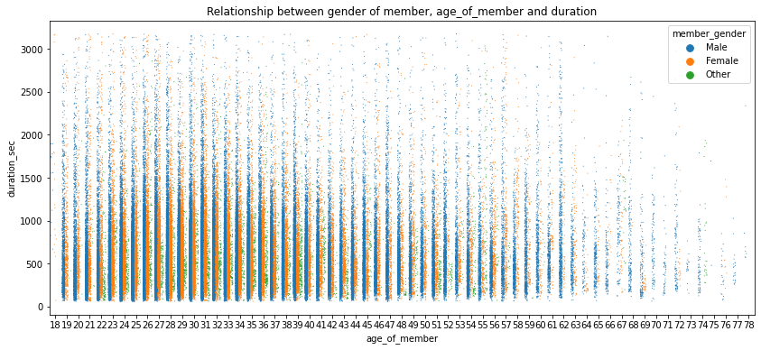

```python
plt.figure(figsize=[14,6])

sb.stripplot(data=df.query('duration_sec<duration_sec.quantile(0.99) and age_of_member<80'),
            x='age_of_member', y='duration_sec', hue='member_gender',
            jitter=0.35, dodge=True, size=1)
plt.title('Relationship between gender of member, age_of_member and duration');
```

## References

- https://towardsdatascience.com/violin-plots-explained-fb1d115e023d